# Communicate Data Finidings > Ford GoBike System Data

## by Abdallah Sayed Ali

#### This dataset includes information about individual rides made in a bike-sharing system covering the greater New York City, NY. This notebook will perform analyzing + Visaulaiztion for answering relevant questions. The dataset find citibikenyc's trip data for public use and its date modified was in Jun 1st 2020 with data has been collected in 2013

data set's link=https://www.citibikenyc.com/system-data

### The Data

Each trip is anonymized and includies:

- Trip Duration (seconds)
- Start Time and Date
- Stop Time and Date
- Start Station Name
- End Station Name
- Station ID
- Station Lat/Long
- Bike ID
- User Type (Customer = 24-hour pass or 3-day pass user; Subscriber = Annual Member)
- Gender (Zero=unknown; 1=male; 2=female)
- Year of Birth

The data has been processed to remove trips that are taken by staff as they service and inspect the system; and any trips that were below 60 seconds in length (potentially false starts or users trying to re-dock a bike to ensure it was secure

## Data wrangling

###### we have unuseful columns:

we could use station name intead of all of those columns

"end station latitude", "end station longitude", "end station id", "start station latitude", "start station longitude", "start station id"

###### we have missing values = 240321 in birth year column

###### Time of timing types >> Data Variable

we could extract start time and end time for (months,days,hours)

```
6    577702
7         1
Name: month, dtype: int64
```

### What is the structure of your dataset?

This dataset have includies about 577,703 Fordgobike tha happened in 2013 in New York.

The dataset contained features about:

1-trip_duration = (start or end time) how long thr trip took in seconds

2-stations = (start or end) station_name and geolocation(latitude or longitude)

3-customer data = user_type

4-rented bikes: bike_id

The dataset has just enhanced with other features that will be used to perform interestin analysis > retal time= moth,day hour pf the day (start and end time)

### What is/are the main feature(s) of interest in your dataset?

The main feature of interest in my dataset is rental time and stations(station_name) which we will figure out when & where bikes are high in demand

also we could know that with if the user is a subscriber or customer

### What features in the dataset do you think will help support your investigation into your feature(s) of interest?

Stations: (start and end) station_name

start_time >>start_month, start_day, start_hour

those will be nessary in bike demanding

## Univariate Exploration

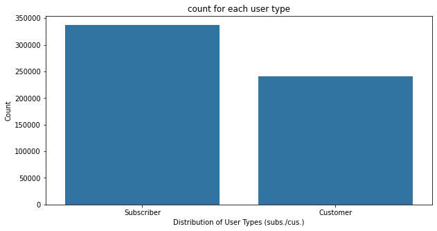

### Graph for Users Age

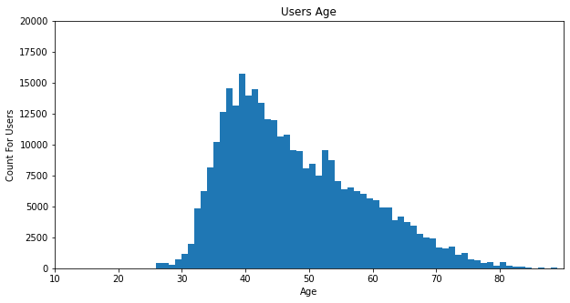

### Time of the trip per minutes

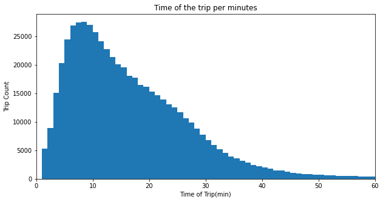

### Time of the trip per hour

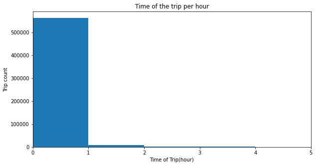

### Discuss the distribution(s) of your variable(s) of interest. Were there any unusual points? Did you need to perform any transformations?

the duration per hour graph shows that there are outlier (approx 4200 trips) compared to the sum of the trips (577703 trips)

### Of the features you investigated, were there any unusual distributions? Did you perform any operations on the data to tidy, adjust, or change the form of the data? If so, why did you do this?

I've converted duration(sec) column to duration(per min) and duration(per hour) by creating new coloumn for each and I've extracted the start day, month, hour from the start time of the trip in a new column for each to explore the data more easly

## Bivariate Exploration

### The Relation Between Age of Users & Trip duration(min)

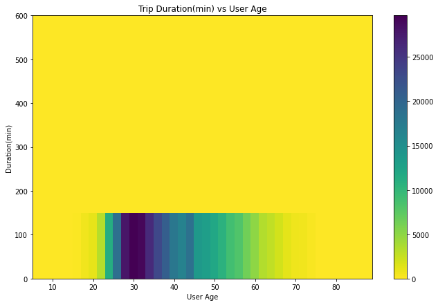

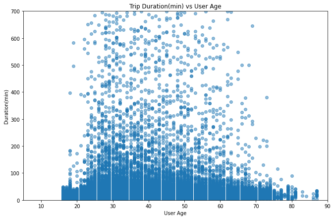

### The relation between user type and the duration of the trip(min)

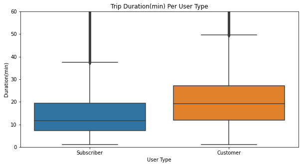

### The relation between the Weekdays and the duration of the trip(min)

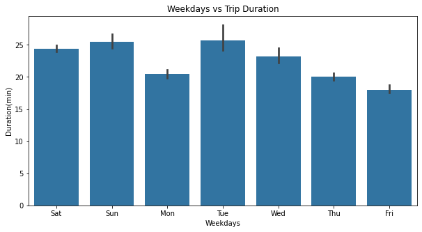

### The relation between Time Trip Start(hour) and the duration of the trip(min)

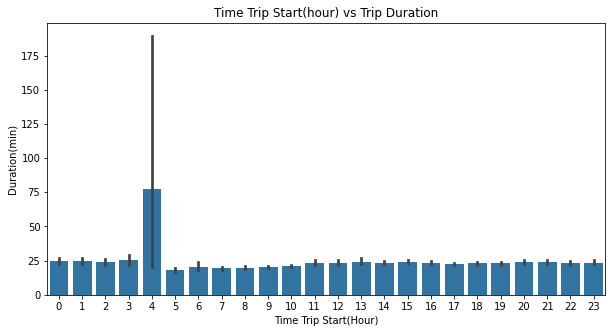

### Talk about some of the relationships you observed in this part of the investigation. How did the feature(s) of interest vary with other features in the dataset?

although the number of Subscribers are 337384 and number of Cutomers are 240319 (97065 differnce)

the customers are spent more time(duration of the trip) than Subscribers

the relation between weekdays and duration of the trips indicate that Saturday, Sunday, Tuesday and Wednesday have higher trip duration for Monday, Thursday and Friday

younger users ride bikes more than older with higher duration

## Multivariate Exploration

### Bike Sharing System per hour and User type

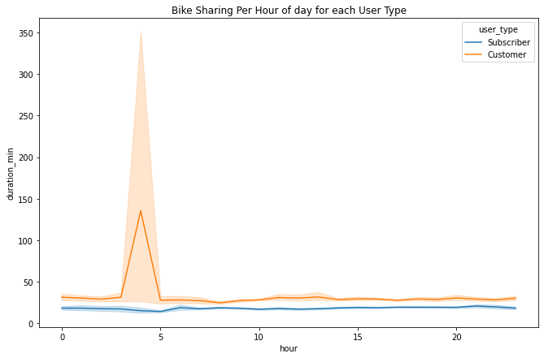

### Bike Sharing System Per Month For each User Type

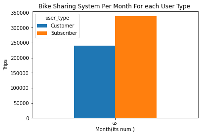

### Weekly Usage during Weekdays for Customers and Subscribers

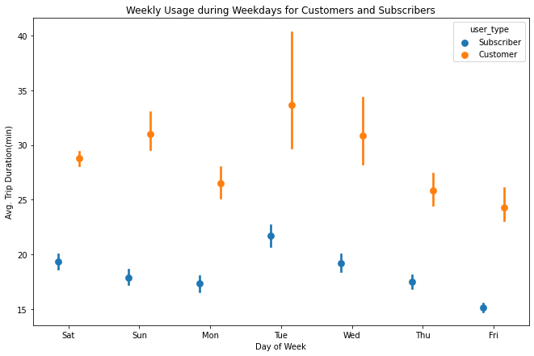